# `rtviz` Tutorial

See the [rtviz github repository here](https://github.com/ThunderShiviah/runtime_visualizer).

## Introduction

`rtviz` is a small library for visualizing the runtimes of certain functions in python.

`rtviz` works by mapping a function over a list of lists and plotting the runtime of each function call agains the length of the list element.

## Quickstart

```python
from rtviz import rtviz
%matplotlib inline
```

```python
help(rtviz)
```

```
Help on function rtviz in module rtviz.main:

rtviz(func, *args, max_size=1000, num_samples=500, viz=True, verbose=True)
    Takes in a function that receives an iterable as input.
    Returns a plot of the runtimes over iterables of random integers of increasing length.

    func: a function that acts on an iterable
```

```
sorted took 110.733ms.
```

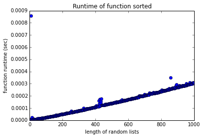

```python
rtviz(sorted)
```

# Extended explanation

*The below table is borrowed from the [python time complexity page](https://wiki.python.org/moin/TimeComplexity).

The [big O runtime values](https://en.wikipedia.org/wiki/Analysis_of_algorithms#Orders_of_growth) correspond to increasing the input size that we run our algorithms against. We get the average case of runtimes if we run our algorithms on randomly generated lists.

list

| **Operation** | **Average Case** | **[Amortized Worst Case](http://en.wikipedia.org/wiki/Amortized_analysis)** |
| --- | --- | --- |
| Copy | O(n) | O(n) |
| Append[1] | O(1) | O(1) |
| Insert | O(n) | O(n) |
| Get Item | O(1) | O(1) |
| Set Item | O(1) | O(1) |
| Delete Item | O(n) | O(n) |
| Iteration | O(n) | O(n) |
| Get Slice | O(k) | O(k) |
| Del Slice | O(n) | O(n) |
| Set Slice | O(k+n) | O(k+n) |
| Extend[1] | O(k) | O(k) |
| [Sort](http://svn.python.org/projects/python/trunk/Objects/listsort.txt) | O(n log n) | O(n log n) |
| Multiply | O(nk) | O(nk) |
| x in s | O(n) |  |
| min(s), max(s) | O(n) |  |
| Get Length | O(1) | O(1) |

The big O runtime values can be visualized as the runtime of an algorithm vs. the size of a data structure (in our case a list) the algorithm runs on.

[figure not shown]

We can check that the big O runtime values are true by explicitly plotting the runtime of an algorithm against the length of randomly generated lists.

For instance, from the above table we see calling the `max` function on a list runs on the order of the length of the list ($O(n)$), while calling the `len` function (which returns the length of a list) should be constant time ($O(1)$) no matter what size list we call it on.

Let's see if this is true:

We first call `rtviz` with the function `max`.

```
max took 30.693ms.
```

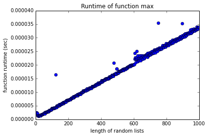

```python
rtviz(max) # Linear
```

Sure enough, we see a linear relationship between runtime of the `max` function and list length.

Next we call `len`, which we would expect to be constant time ($O(1)$).

```
len took 30.307ms.
```

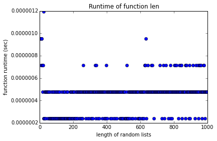

```python
rtviz(len)
```

We see that the runtimes of the `len` method are indeed flat, therefore the runtime is constant.

There is however something a bit unexpected about our graph of the `len` function: we see multiple lines!

If we instead try calling `__len__` which returns the length of an object, we still get the same behavior.

```python
def length(lst):
    return lst.__len__()

assert length([1,2,3]) == 3
```

```
length took 17.286ms.
```

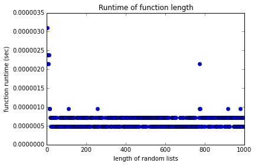

```python
rtviz(length)
```

Use of rtviz often reveals interesting insights into python's actual implementation. In this case, by visualizing the `len` method, we are actually seeing the lookup time of a hash table implemented in C. Although the average runtime is constant (as evidenced by the flat lines), depending on how good the hash of our `__len__` attribute is we get faster or slower performance (as evidenced by the multiple stacked lines). See [this blog post](http://www.laurentluce.com/posts/python-list-implementation/) and the original [python object implementation in c](http://www.laurentluce.com/posts/python-list-implementation/) for more details.